# Analytics Bootcamp

Local Regression, Introduction

Friday, October 19, 2018

# 1 Overview

In today’s class, we’ll discuss:

- About me, you, the course, and such.
- What machine learning is, beginning with a simple model.

# 2 About

## 2.1 About me

A data scientist and teaching assistant at UBC for the MBA, Supply Chain Analytics course. My background:

- Bachelor of Technology in Computer Science & Engineering
- Master in Business Analytics
- Decision Scientist, Mu Sigma
- Analytical Consultant, Boeing Vancouver
- Co-founder, Cleo

Computationally, I am primarily an R programmer. I’m a basic python user.

Lots of experience as a statistical consultant for businesses.

## 2.2 About the TA’s

This course has one TA.

- Arya, she loves google.

You’ll see them in class and office hours.

## 2.3 About you

Introduce yourself! Let’s hear about:

- Your name
- Why Analytics?
- Something about yourself.

## 2.4 About this course

This is an introductory course! You can expect things to evolve as we progress.

- Preview of the course website – it contains all materials related to the course.
- Preview of the syllabus

Before we talk more about the assessments, let’s first talk about the structure of our class meetings.

## 2.5 About class meetings

I intend most class meetings to take the **listen-do-listen-do** form:

1. **Listen**: (15 min?) I’ll start class meetings with high-level explanations of a topic.
2. **Do**: (40 min?) You do hands-on exploratory work to allow you to build concepts.
   - You “present” your work to initiate a class discussion; I clarify concepts as needed.
3. **Listen**: (25 min?) Once you have basic concepts down pat, I’ll talk more about details. Maybe iterate back to 1 with another topic.
4. **Do**: (40 min?) Open time for working on course material, typically assignments or in-class material. Instructor and a TA will be present to answer questions.

Notes:

- This structure might evolve as the course progresses.
- There will be a TA present to help you.
- In-class exercises will typically contain toy data sets; assignments will be more “real”.

# 3 Local machine learning methods

Let’s turn our attention to the first “new” machine learning methods : $k$ **Nearest Neighbours** (aka kNN or $k$-NN) and **loess** (aka “LOcal regrESSion”).

The fundamental idea behind these methods is to *base your prediction on what happened in similar cases in the past*.

## 3.1 kNN

Pick a positive integer $k$.

To make a prediction of the response at a particular observation of the predictors (I’ll call this the **query point**) – that is, when $X_1=x_1$, …, $X_p=x_p$:

1. Subset your data to $k$ observations (rows) whose values of the predictors $(X_1, \ldots, X_p)$ are closest to $(x_1,\ldots,x_p)$.
2. For kNN classificiation, use the “most popular vote” (i.e., the modal category) of the subsetted observations. For kNN regression, use the average $Y$ of the remaining subsetted observations.

Recall how to calculate distance between two vectors $(a_1, \ldots, a_p)$ and $(b_1, \ldots, b_p)$:
$$\text{distance} = \sqrt{(a_1-b_1)^2 + \cdots + (a_p-b_p)^2}.$$
It’s even easier when there’s one predictor: it’s just the absolute value of the difference.

## 3.2 loess

(This is actually the simplest version of loess, sometimes called a **moving window** approach. We’ll get to the “full” loess).

Pick a positive number $r$ (not necessarily integer).

To make a prediction of the response at a query point (that is, a particular observation of the predictors, $X_1=x_1$, …, $X_p=x_p$):

1. Subset your data to those observations (rows) having values of the predictors $(X_1,\ldots,X_p)$ within $r$ units of $(x_1,\ldots,x_p)$.
2. For kNN classificiation, use the “most popular vote” (i.e., the modal category) of the subsetted observations. For kNN regression, use the average $Y$ of the remaining subsetted observations.

Notice that Step 2 is the same as in kNN.

$k$ and $r$ are called **hyperparameters**, because we don’t estimate them – we choose them outright.

# 4 In-Class Exercises

Consider the following data set, given by `dat`. Here’s the top six rows of data:

```r
set.seed(87)
dat <- tibble(x = c(rnorm(100), rnorm(100)+5)-3,
              y = sin(x^2/5)/x + rnorm(200)/10 + exp(1))
kable(head(dat))
```

| x | y |
| --- | --- |
| -5.142691 | 2.823462 |
| -4.722812 | 2.759020 |
| -4.871821 | 3.043214 |
| -3.915033 | 2.716712 |
| -1.164387 | 2.412004 |
| -3.104414 | 2.325320 |

Here’s a scatterplot of the data:

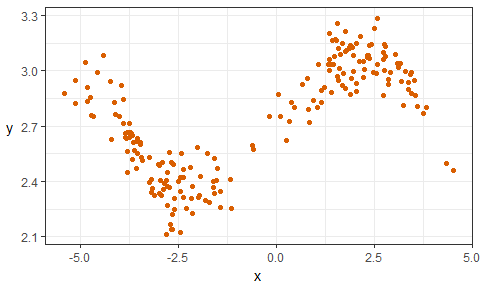

```r
ggplot(dat, aes(x,y)) +
    geom_point(colour=my_accent) +
    theme_bw() +
    rotate_y
```

## 4.1 Exercise 1: Mean at $X=0$

Let’s check your understanding of loess and kNN. Consider estimating the mean of $Y$ when $X=0$ by using data whose $X$ values are near 0.

1. Eyeball the above scatterplot of the data. What would you say is a reasonable estimate of the mean of $Y$ at $X=0$? Why?

> The data seem to be centered around approximately 2.7. 2. Estimate using loess and kNN (you choose the hyperparameters). 1. Hints for kNN: - First, add a new column in the data that stores the *distance* between $X=0$ and each observation. If that column is named `d`, you can do this with the following partial code: `dat$d <- YOUR_CALCULATION_HERE`. Recall that `dat$x` is a vector of the `x` column. - Then, arrange the data from smallest distance to largest with `arrange(dat)` (you’ll need to load the `tidyverse` package first), and subset *that* to the first $k$ rows. 2. Hints for loess: - Subset the data using the `filter` function. The condition to filter on: you want to keep rows whose distances (`d`) are …

```r
k <- 10
r <- 0.5
dat %>%
    mutate(d = abs(x-0)) %>%
    arrange(d) %>%
    summarize(kNN=mean(y[1:k]),
              loess=mean(y[d<r])) %>%
    kable
```

| kNN | loess |
| --- | --- |
| 2.744816 | 2.764507 |

3. What happens when you try to pick an $r$ that is way too small? Say, $r=0.01$? Why?

> There will be no prediction, because there will be no data in the window. Here’s the data that result after subsetting:

```r
r <- 0.01
dat %>%
    mutate(d = abs(x-0)) %>%
    filter(d<r)
```

```
## # A tibble: 0 x 3
## # ... with 3 variables: x <dbl>, y <dbl>, d <dbl>
```

## 4.2 Exercise 2: Regression Curve

Instead of estimating the mean just at $X=0$, we’d like to do the same procedure, but for “all” $X$ values, keeping the hyperparameter fixed. Because we can’t actually do this for all $X$ values, let’s choose a grid of 1000 $X$ values between -5 and 4 using the code `seq(-5, 4, length.out=1000)`.

**Questions for discussion**:

- Go ahead and do the estimation using both methods, and plot the mean estimates for each $X$ on top of the scatterplot in a different colour, connecting the dots to form a **regression curve**. I’ll give you some of the code – just fill in your code for the kNN and loess exercise from before:

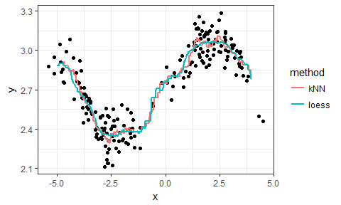

```r
library(tidyverse)
xgrid <- seq(-5, 4, length.out=1000)
k <- 10
r <- 0.5
kNN_estimates <- map_dbl(xgrid, function(x_){
    dat %>%
        mutate(d = abs(x-x_)) %>%
        arrange(d) %>%
        summarize(yhat=mean(y[1:k])) %>%
        `[[`("yhat")
})
loess_estimates <- map_dbl(xgrid, function(x_){
    dat %>%
        mutate(d = abs(x-x_)) %>%
        filter(d<r) %>%
        summarize(yhat=mean(y)) %>%
        `[[`("yhat")
})
est <- tibble(x=xgrid, kNN=kNN_estimates, loess=loess_estimates) %>%
    gather(key="method", value="estimate", kNN, loess)
ggplot() +
    geom_point(data=dat, mapping=aes(x,y)) +
    geom_line(data=est,
              mapping=aes(x,estimate, group=method, colour=method),
              size=1) +
    theme_bw()
```

- Play with different values of $k$ and $r$, and regenerate the plot each time. What effect does increasing these values have on the regression curve? What about decreasing? What would you say is a “good” choice of $k$ and $r$, and why?
- What happens when you choose $k=n=200$? What happens if you choose $r=10$ or bigger?

## 4.3 Food for Thought

The phenomenon you see when $k$ and $r$ are very small is called **overfitting**. This means that your model displays patterns that are not actually present. **Underfitting**, on the other hand, is when your model misses patterns in the data that are actually present.